## Classification in Machine Learning

Ini merupakan analisis dataset *loan* (pinjaman bank) yang menyimpan *data historis nasabah bank yang cenderung default (gagal bayar pinjaman) atau tidak*. Data tersimpan dalam repositori ini sebagai `loan.csv`. Akan dibuat model klasifikasi menggunakan algoritma Naive Bayes, Decision Tree, dan Random Forest dengan langkah-langkah berikut:

# Library

Sebelum memulai analisi data, berikut ini adalah library set yang perlu dipanggil untuk mendukung proses analisis data di R Studio

```r
library(dplyr)
library(e1071)
library(caret)
library(ROCR)
library(partykit)
library(rsample)
library(randomForest)
```

# Eksplorasi Data

Sebelum membuat model, data akan dieksplorasi terlebih dahulu. Proses pertama data (`loan.csv`) akan diakses/dibaca oleh R dan disimpan ke dalam objek bernama`loan`, kemudian data dicek secara singkat menggunakan fungsi `str()` atau `glimpse()`.

```r
loan <- read.csv("loan.csv", stringsAsFactors = T)
str(loan)
```

```
## 'data.frame':    1000 obs. of  17 variables:
##  $ checking_balance    : Factor w/ 4 levels "< 0 DM","> 200 DM",..: 1 3 4 1 1 4 4 3 4 3 ...
##  $ months_loan_duration: int  6 48 12 42 24 36 24 36 12 30 ...
##  $ credit_history      : Factor w/ 5 levels "critical","good",..: 1 2 1 2 4 2 2 2 2 1 ...
##  $ purpose             : Factor w/ 6 levels "business","car",..: 5 5 4 5 2 4 5 2 5 2 ...
##  $ amount              : int  1169 5951 2096 7882 4870 9055 2835 6948 3059 5234 ...
##  $ savings_balance     : Factor w/ 5 levels "< 100 DM","> 1000 DM",..: 5 1 1 1 1 5 4 1 2 1 ...
##  $ employment_duration : Factor w/ 5 levels "< 1 year","> 7 years",..: 2 3 4 4 3 3 2 3 4 5 ...
##  $ percent_of_income   : int  4 2 2 2 3 2 3 2 2 4 ...
##  $ years_at_residence  : int  4 2 3 4 4 4 4 2 4 2 ...
##  $ age                 : int  67 22 49 45 53 35 53 35 61 28 ...
##  $ other_credit        : Factor w/ 3 levels "bank","none",..: 2 2 2 2 2 2 2 2 2 2 ...
##  $ housing             : Factor w/ 3 levels "other","own",..: 2 2 2 1 1 1 2 3 2 2 ...
##  $ existing_loans_count: int  2 1 1 1 2 1 1 1 1 2 ...
##  $ job                 : Factor w/ 4 levels "management","skilled",..: 2 2 4 2 2 4 2 1 4 1 ...
##  $ dependents          : int  1 1 2 2 2 2 1 1 1 1 ...
##  $ phone               : Factor w/ 2 levels "no","yes": 2 1 1 1 1 2 1 2 1 1 ...
##  $ default             : Factor w/ 2 levels "no","yes": 1 2 1 1 2 1 1 1 1 2 ...
```

Berdasarkan investigasi di atas, data loan memiliki 1000 observasi dan 17 variabel. Berikut adalah deskripsi detail dari setiap kolom:

- `checking_balance` dan `savings_balance`: Status akun checking/savings yang ada
- `months_loan_duration`: Durasi periode pinjaman (dalam bulan)
- `credit_history`: Status kredit yang terdiri dari *critical* (kritis), *good* (baik), *perfect* (sempurna), *poor* (buruk), dan *very good* (sangat baik)
- `purpose`: Tujuan mengajukan pinjaman yang terdiri dari *business* (bisnis), *car(new)* (mobil baru), *car(used)* (mobil bekas), *education* (pendidikan), *furniture* (perabot rumah), dan *renovations* (renovasi)
- `amount`: Jumlah pinjaman dalam DM (Deutsche Mark)
- `employment_duration`: Durasi bekerja pada pekerjaan saat ini
- `percent_of_income`: Tingkat angsuran dalam persentase pendapatan bebas pajak
- `years_at_residence`: Durasi tinggal di alamat domisili saat ini (dalam tahun)
- `age`: Umur nasabah
- `other_credit`: Rencana cicilan lainnya (bank/store)
- `housing`: Kepemilikan rumah yang terdiri dari *rent* (sewa), *own* (milik sendiri), atau *for free* (gratis)
- `existing_loans_count`: Jumlah pinjaman yang sedang berjalan
- `job`: Pekerjaan yang terdiri dari *management* (manajemen), *skilled* (ahli), *unskilled* (tidak ahli) dan *unemployed* (pengangguran)
- `dependents`: Jumlah orang yang bertanggung jawab untuk melakukan pemeliharaan
- `phone`: Apakah terdaftar atas nama nasabah (antara *yes*/*no*)
- `default`: Apakah nasabah gagal bayar/*charged off*/lewat tanggal jatuh tempo (antara *yes*/*no*).

Kita juga perlu memastikan bahwa setiap kolom telah menyimpan tipe data yang tepat.

*Tips: Anda dapat menggunakan parameter `stringsAsFactors = TRUE` dari `read.csv()` sehingga semua kolom karakter akan otomatis disimpan sebagai faktor.*

```r
head(loan)
```

```
##   checking_balance months_loan_duration credit_history              purpose
## 1           < 0 DM                    6       critical furniture/appliances
## 2       1 - 200 DM                   48           good furniture/appliances
## 3          unknown                   12       critical            education
## 4           < 0 DM                   42           good furniture/appliances
## 5           < 0 DM                   24           poor                  car
## 6          unknown                   36           good            education
##   amount savings_balance employment_duration percent_of_income
## 1   1169         unknown           > 7 years                 4
## 2   5951        < 100 DM         1 - 4 years                 2
## 3   2096        < 100 DM         4 - 7 years                 2
## 4   7882        < 100 DM         4 - 7 years                 2
## 5   4870        < 100 DM         1 - 4 years                 3
## 6   9055         unknown         1 - 4 years                 2
##   years_at_residence age other_credit housing existing_loans_count       job
## 1                  4  67         none     own                    2   skilled
## 2                  2  22         none     own                    1   skilled
## 3                  3  49         none     own                    1 unskilled
## 4                  4  45         none   other                    1   skilled
## 5                  4  53         none   other                    2   skilled
## 6                  4  35         none   other                    1 unskilled
##   dependents phone default
## 1          1   yes      no
## 2          1    no     yes
## 3          2    no      no
## 4          2    no      no
## 5          2    no     yes
## 6          2   yes      no
```

Pinjaman adalah hal yang berisiko, namun pada saat yang sama juga menghasilkan keuntungan bagi lembaga melalui suku bunga pinjaman. **Mengidentifikasi nasabah yang berisiko tinggi untuk gagal bayar** adalah salah satu cara untuk meminimalisir kerugian pemberi pinjaman. Untuk itu, kita akan coba memprediksi kemungkinan nasabah gagal bayar menggunakan prediktor-prediktor yang disediakan.

Sebelum melakukan modeling, data akan dieksplorasi. Untuk menyelidiki jumlah historis nasabah yang gagal bayar dari setiap tujuan pinjaman akan dilakukan agregasi data untuk mendapatkan jawabannya.

*Karena kita hanya fokus pada nasabah yang default/gagal bayar, data historis akan difilter dengan kondisi yang dibutuhkan (default == “yes”)*

```r
# code here
library(dplyr)
filter_loan <- loan %>%
  filter(default == "yes")
filter_loan
```

[output not shown]

[output cut: 1189 more lines]

```r
prop.table(table(filter_loan$purpose))
```

```
##
##             business                  car                 car0
##           0.11333333           0.35333333           0.01666667
##            education furniture/appliances          renovations
##           0.07666667           0.41333333           0.02666667
```

# Cross-Validation

Sebelum membuat model, dataset akan dibagi menjadi data train dan test dengan proporsi 80% train dan 20% test menggunakan fungsi `sample()`, `set.seed(100)`, dan disimpan ke dalam obyek `data_train` dan `data_test`.

> Note: Akan digunakan fungsi `RNGkind()` dan `set.seed()` sebelum membagi data dan menjalankannya bersamaan dengan code `sample()`.

```r
RNGkind(sample.kind = "Rounding")
set.seed(100)
# code here
index <- sample(nrow(loan), nrow(loan)*0.8)
loan_train <- loan[index,]
loan_test <- loan[-index,]
```

Mari kita lihat proporsi kelas target pada data train menggunakan fungsi `prop.table (table(object$target))` untuk memastikan data train memiliki proporsi kelas target yang seimbang.

```r
# code here
prop.table(table(loan_train$default))
```

```
##
##     no    yes
## 0.6775 0.3225
```

Berdasarkan proporsi di atas, dapat disimpulkan bahwa proporsi kelas target tidak seimbang; kita harus menyeimbangkannya sebelum menggunakannya pada model kita. Satu hal penting yang harus diingat adalah semua metode sub-sampling hanya boleh diterapkan pada data train. Metode *downsampling* pada `data_train` akan dilakukan menggunakan fungsi `downSample()` dari package caret, data downsample akan disimpan dalam objek `data_train_down`.

> Note: parameter `yname = "default"`

```r
library(caret)
set.seed(100)
# code here
data_train_down <- downSample(x = loan_train %>% select(-default),
                         y = loan_train$default,
                         yname = "default")
```

```r
prop.table(table(data_train_down$default))
```

```
##
##  no yes
## 0.5 0.5
```

> Untuk tahapan selanjutnya, akan digunakan `data_train_down` untuk pembuatan model Naive Bayes, Decision Tree, dan Random Forest.

# Naive Bayes

Setelah membagi data menjadi data train dan test serta melakukan downsample pada data train, mari kita buat model pertama dengan algoritma Naive Bayes.

Pembuatan model Naive Bayes akan menggunakan fungsi `naiveBayes()` dari package `e1071`, lalu atur parameter `laplace = 1`. Model akan disimpan ke dalam objek `model_naive` sebelum melanjutkan ke tahap berikutnya.

```r
library(e1071)
# code here
model_naive <- naiveBayes(x = data_train_down %>% select(-default),
                          y = data_train_down$default,
                          laplace = 1)
```

# Prediksi Model Naive Bayes

Prediksi data test dilakukan menggunakan `model_naive`. Fungsi `predict()` digunakan dengan parameter `type = "class"` untuk mendapatkan prediksi kelas. Hasil prediksi akan disimpan ke dalam objek `pred_naive`.

```r
# code here
pred_naive <- predict(object = model_naive,
        newdata = loan_test,
        type = "class")
```

# Evaluasi Model Naive Bayes

Evaluasi model dilkukan menggunakan `confusionMatrix()` dan membandingkan kelas hasil prediksi (`pred_naive`) dengan label sebenarnya dari `data_test`.

```r
# code here
confusionMatrix(data = pred_naive,
                reference = loan_test$default, positive = "yes")
```

```
## Confusion Matrix and Statistics
##
##           Reference
## Prediction  no yes
##        no  108  14
##        yes  50  28
##
##                Accuracy : 0.68
##                  95% CI : (0.6105, 0.744)
##     No Information Rate : 0.79
##     P-Value [Acc > NIR] : 0.9999
##
##                   Kappa : 0.2664
##
##  Mcnemar's Test P-Value : 1.214e-05
##
##             Sensitivity : 0.6667
##             Specificity : 0.6835
##          Pos Pred Value : 0.3590
##          Neg Pred Value : 0.8852
##              Prevalence : 0.2100
##          Detection Rate : 0.1400
##    Detection Prevalence : 0.3900
##       Balanced Accuracy : 0.6751
##
##        'Positive' Class : yes
##
```

# Decision Tree

Mari buat model Decision Tree menggunakan fungsi `ctree()` dan simpan ke dalam objek `model_dt`. Untuk melakukan *tuning* model, mari kita atur parameter `mincriterion = 0.90`.

```r
library(partykit)
set.seed(100)
# code here
model_dt <- ctree(formula = default ~.,
                  data = data_train_down,
                  control = ctree_control(mincriterion = 0.90))
model_dt
```

```
##
## Model formula:
## default ~ checking_balance + months_loan_duration + credit_history +
##     purpose + amount + savings_balance + employment_duration +
##     percent_of_income + years_at_residence + age + other_credit +
##     housing + existing_loans_count + job + dependents + phone
##
## Fitted party:
## [1] root
## |   [2] checking_balance < 0 DM, > 200 DM, 1 - 200 DM
## |   |   [3] credit_history in critical, poor
## |   |   |   [4] months_loan_duration <= 16: no (n = 33, err = 24.2%)
## |   |   |   [5] months_loan_duration > 16: yes (n = 64, err = 43.8%)
## |   |   [6] credit_history in good, perfect, very good
## |   |   |   [7] savings_balance < 100 DM, > 1000 DM, 100 - 500 DM: yes (n = 198, err = 25.8%)
## |   |   |   [8] savings_balance in 500 - 1000 DM, unknown: no (n = 45, err = 48.9%)
## |   [9] checking_balance in unknown
## |   |   [10] other_credit in bank, store: yes (n = 34, err = 44.1%)
## |   |   [11] other_credit in none
## |   |   |   [12] credit_history in critical, perfect
## |   |   |   |   [13] amount <= 5103: no (n = 46, err = 2.2%)
## |   |   |   |   [14] amount > 5103: no (n = 7, err = 28.6%)
## |   |   |   [15] credit_history in good, poor
## |   |   |   |   [16] existing_loans_count <= 1: no (n = 71, err = 18.3%)
## |   |   |   |   [17] existing_loans_count > 1: yes (n = 18, err = 44.4%)
##
## Number of inner nodes:    8
## Number of terminal nodes: 9
```

Untuk mendapatkan pemahaman yang lebih baik tentang model, buat plot dari model dan gunakan parameter `type = "simple"`.

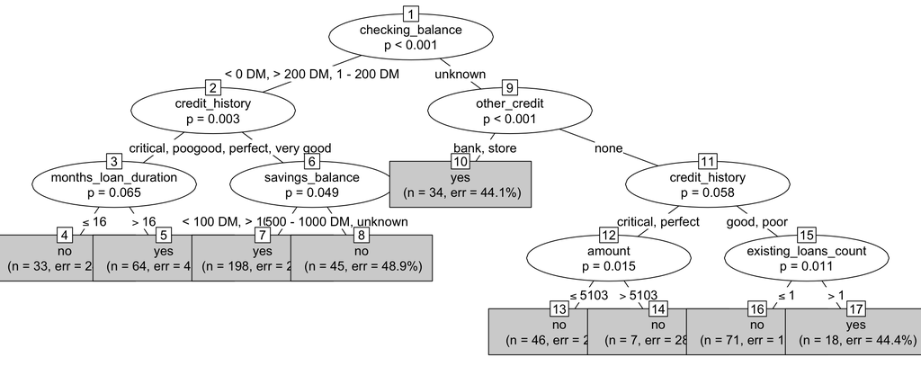

```r
# code here
plot(model_dt, type = "simple")
```

Berdasarkan plot di atas, nasabah dengan `checking_balance` tercatat “unknown” (tidak diketahui), dan `other_credit` berupa “store” diekspektasikan akan default

# Prediksi Model Decision Tree

Setelah kita membuat model, akan dilakukan prediksi ke data test berdasarkan `model_dt` menggunakan fungsi `predict()` dengan mengatur parameter `type = "response"`.

```r
# code here
pred_dt <- predict(object = model_dt,
                                newdata = loan_test,
                                type = "response")
```

# Evaluasi Model Decision Tree

Untuk memeriksa performa model, kita dapat menggunakan `confusionMatrix()`.

```r
# code here
confusionMatrix(data = pred_dt,reference = loan_test$default,
                positive = "yes")
```

```
## Confusion Matrix and Statistics
##
##           Reference
## Prediction no yes
##        no  83   6
##        yes 75  36
##
##                Accuracy : 0.595
##                  95% CI : (0.5235, 0.6637)
##     No Information Rate : 0.79
##     P-Value [Acc > NIR] : 1
##
##                   Kappa : 0.2386
##
##  Mcnemar's Test P-Value : 4.171e-14
##
##             Sensitivity : 0.8571
##             Specificity : 0.5253
##          Pos Pred Value : 0.3243
##          Neg Pred Value : 0.9326
##              Prevalence : 0.2100
##          Detection Rate : 0.1800
##    Detection Prevalence : 0.5550
##       Balanced Accuracy : 0.6912
##
##        'Positive' Class : yes
##
```

# Random Forest

Model terakhir yang ingin kita buat adalah Random Forest. Eksplorasi model random forest menggunakan `model_rf.RDS`. Model tersebut dibuat menggunakan *hyperparameter* di bawah ini:

- `set.seed(100)` # angka seed
- `number = 5` # jumlah k-fold cross-validation
- `repeats = 3` # jumlah iterasi

Model Random Forest tersebut (`model_rf.RDS`) dibaca menggunakan fungsi `readRDS()` dan simpan ke dalam objek `model_rf`.

```r
# code here
model_rf <- readRDS("model_rf.RDS")
```

Rangkuman final model dari model Random Forest dibuat menggunakan `model_rf$finalModel`

```r
library(randomForest)
# code here
model_rf$finalModel
```

```
##
## Call:
##  randomForest(x = x, y = y, mtry = param$mtry)
##                Type of random forest: classification
##                      Number of trees: 500
## No. of variables tried at each split: 2
##
##         OOB estimate of  error rate: 33.61%
## Confusion matrix:
##      no yes class.error
## no  158  80   0.3361345
## yes  80 158   0.3361345
```

Dalam praktiknya, random forest telah memiliki estimasi out-of-bag (OOB) yang merepresentasikan akurasi pada *out-of-bag data* (data yang tidak diambil ketika sampling/tidak digunakan dalam pembuatan random forest). Kita memiliki error 33.61% pada data train.

Kita juga bisa menggunakan informasi *Variable Importance*, untuk mendapatkan daftar variabel penting yang digunakan pada model Random Forest. Banyak yang berargumen bahwa Random Forest, sebgai model *Black Box*, tidak dapat menawarkan informasi penting lain selain akurasinya yang amat tinggi. Namun, memberikan perhatian khusus pada atribut seperti *Variable Importance* sering kali membantu kita dalam mendapatkan informasi berharga tentang data.

Berikut akan ditentukan variabel yang memiliki pengaruh penting dalam menghasilkan prediksi (*Variable Importance*) menggunakan fungsi `varImp()`, kemudian dimasukkan ke dalam fungsi `plot()` untuk mendapatkan visualisasinya.

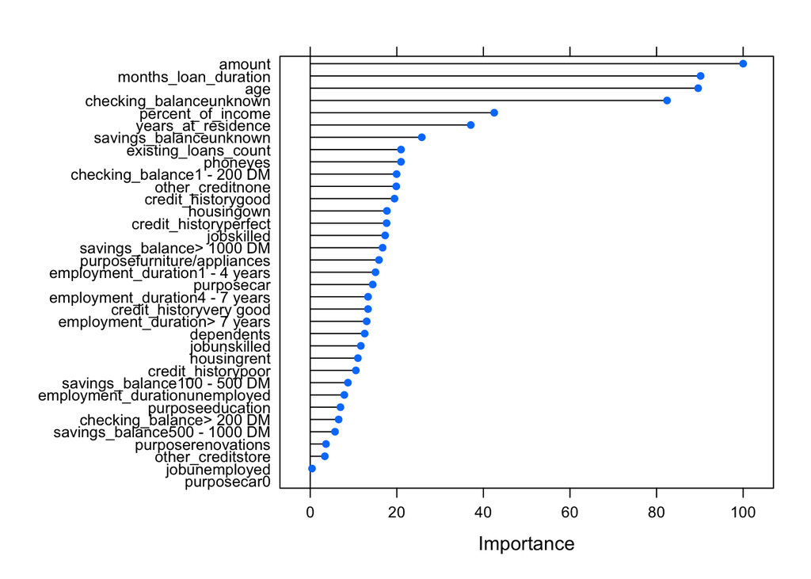

```r
# code here
plot(varImp(model_rf))
```

# Prediksi Model Random Forest

Setelah membangun model, kita dapat memprediksi data test menggunakan `model_rf`. Gunakan fungsi `predict()` dan atur parameter `type = "raw"` untuk mendapatkan prediksi kelas.

```r
# code here
pred_rf <- predict(model_rf, newdata=loan_test, type = "raw")
```

# Evaluasi Model Random Forest

Selanjutnya, mari kita evaluasi model random forest dengan fungsi `confusionMatrix()`.

```r
# code here
confusionMatrix(data = pred_rf, reference = loan_test$default, positive = "yes")
```

```
## Confusion Matrix and Statistics
##
##           Reference
## Prediction  no yes
##        no  123   2
##        yes  35  40
##
##                Accuracy : 0.815
##                  95% CI : (0.7541, 0.8663)
##     No Information Rate : 0.79
##     P-Value [Acc > NIR] : 0.2193
##
##                   Kappa : 0.5673
##
##  Mcnemar's Test P-Value : 1.435e-07
##
##             Sensitivity : 0.9524
##             Specificity : 0.7785
##          Pos Pred Value : 0.5333
##          Neg Pred Value : 0.9840
##              Prevalence : 0.2100
##          Detection Rate : 0.2000
##    Detection Prevalence : 0.3750
##       Balanced Accuracy : 0.8654
##
##        'Positive' Class : yes
##
```

Cara lain untuk mengevaluasi performa model adalah dengan melihat nilai ROC dan AUC-nya. Untuk menghitungnya, kita membutuhkan *probabilitas ke kelas positif untuk setiap observasi*. Mari fokus pada nilai ROC dan AUC dari prediksi model Random Forest. Pertama, lakukan prediksi ke data test menggunakan `model_rf` dengan menggunakan parameter `type = "prob"`. Akan dihasilkan prediksi nilai probabilitas untuk setiap kelas.

```r
# code here
prob_test <- predict(object = model_rf,
                          newdata = loan_test,
                          type = "prob")
```

Sekarang, gunakan fungsi `prediction()` dari package `ROCR` untuk membandingkan probability ke kelas positif yang tersimpan dalam `prob_test[,"yes"]` dengan data aktual `data_test$default`, kemudian simpan ke dalam objek `pred_roc`.

```r
library(ROCR)
# code here
data_roc <- data.frame(pred_prob = prob_test[, "yes"],
                       actual = ifelse(loan_test$default == "yes", 1,0))
pred_roc <- prediction(predictions = data_roc$pred_prob,
                      labels = data_roc$actual)
```

Selanjutnya, gunakan fungsi `performance()` dari package ROCR dengan mendefinisikan axis plot untuk menghasilkan plot ROC. Simpan hasilnya ke dalam objek `perf`. Untuk menggunakan fungsi `performance()`, atur parameter di bawah ini: - `prediction.obj = pred_roc` - `measure = "tpr"` - `x.measure = "fpr"`

```r
# code here
perf <- performance(pred_roc, "tpr","fpr")
```

Setelah membuat objek `perf`, buat plot ROC dengan memasukkan objek `perf` ke dalam fungsi`plot()`.

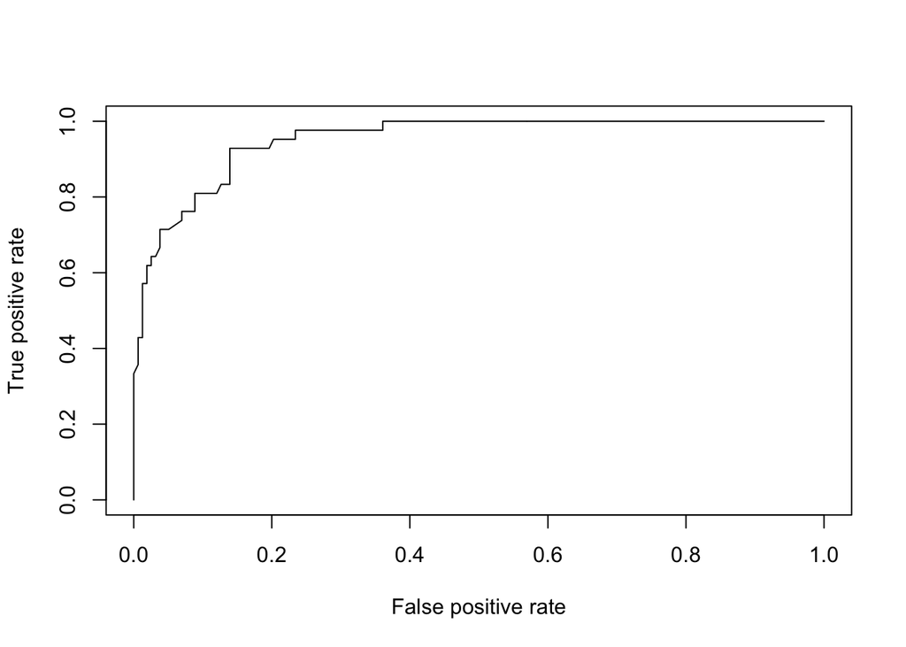

```r
# code here
plot(perf)
```

Evaluasi Kurva ROC; lihat apakah ada hasil yang tidak diinginkan dari model. Selanjutnya, cari nilai AUC menggunakan fungsi `performance()` dengan mengatur parameter `prediction.obj = pred_roc` dan `measure = "auc"` simpan ke dalam objek `auc`.

```r
# code here
auc <- performance(pred_roc, measure = "auc")
auc@y.values
```

```
## [[1]]
## [1] 0.9511001
```